# Comparative Value at Risk analysis in GARCH models

# Introduction

The aim is to compare the risk in the cryptocurrency market, the tests include the estimation of the conditional variance function in the GARCH family models. Performed tests in accordance with the selected products: Ardor, Waves, RavenCoin and Zcash. Three GARCH class models - "GARCH" and its extensions - EGARCH and CGARCH, were estimated. Data sample was scraped from the Coingecko website [LINK](https://github.com/ZawadzkiR/crypto_historical_data/blob/main/crypto_historical.R).

```r
library(rvest)
library(RCurl)
library(xml2)
library(dygraphs)
library(moments)
library(xts)
library(rugarch)
library(car)
library(FinTS)
library(fGarch)
library(tseries)
library(moments)
source('functions.R')
```

# 1. Data preparation and analysis

Data was obtained using web-scraping. They come from the CoinGecko website. For each cryptocurrency, its closing price and capitalization were kept and combined into one data table.

```r
zcash = getdata('zcash', start_date='2018-05-03', end_date='2021-06-11')
waves = getdata('waves', start_date='2018-05-03', end_date='2021-06-11')
ardor = getdata('ardor', start_date='2018-05-03', end_date='2021-06-11')
ravencoin = getdata('ravencoin', start_date='2018-05-03', end_date='2021-06-11')

ardor <- ardor[ ,c("Date", "Close", "MarketCap")]
zcash <- zcash[ ,c("Date", "Close", "MarketCap")]
waves <- waves[ ,c("Date", "Close", "MarketCap")]
ravencoin <- ravencoin[ ,c("Date", "Close", "MarketCap")]

colnames(ardor) <- c("Date", "ardor_close", "ardor_cap")
colnames(zcash) <- c("Date", "zcash_close", "zcash_cap")
colnames(waves) <- c("Date", "waves_close", "waves_cap")
colnames(ravencoin) <- c("Date", "ravencoin_close", "ravencoin_cap")


ardor$Date <- as.Date(ardor$Date)
zcash$Date <- as.Date(zcash$Date)
waves$Date <- as.Date(waves$Date)
ravencoin$Date <- as.Date(ravencoin$Date)

base = merge(zcash, waves, by.x="Date", by.y="Date")
base = merge(base, ardor, by.x="Date", by.y="Date")
base = merge(base, ravencoin, by.x="Date", by.y="Date")
base = na.omit(base)
```

```r
# total
base$tot_cap = base$zcash_cap + base$waves_cap + base$ardor_cap + base$ravencoin_cap
# percentage
base$perc_zcash = (base$zcash_cap/base$tot_cap)
base$perc_waves = (base$waves_cap/base$tot_cap)
base$perc_ardor = (base$ardor_cap/base$tot_cap)
base$perc_ravencoin = (base$ravencoin_cap/base$tot_cap)

#rates of return
library(xts)
#for each currency
base$ret_zcash = diff.xts(log(base$zcash_close))
base$ret_waves = diff.xts(log(base$waves_close))
base$ret_ardor = diff.xts(log(base$ardor_close))
base$ret_ravencoin = diff.xts(log(base$ravencoin_close))

base$tot_ret = (base$ret_zcash*base$perc_zcash
                + base$ret_waves*base$perc_waves
                + base$ret_ardor*base$perc_ardor
                + base$ret_ravencoin*base$perc_ravencoin)


base = na.omit(base)
```

```r
head(base)
```

A data.frame: 6 × 19

|  | Date <date> | zcash_close <dbl> | zcash_cap <dbl> | waves_close <dbl> | waves_cap <dbl> | ardor_close <dbl> | ardor_cap <int> | ravencoin_close <dbl> | ravencoin_cap <dbl> | tot_cap <dbl> | perc_zcash <dbl> | perc_waves <dbl> | perc_ardor <dbl> | perc_ravencoin <dbl> | ret_zcash <dbl> | ret_waves <dbl> | ret_ardor <dbl> | ret_ravencoin <dbl> | tot_ret <dbl> |
| --- | --- | --- | --- | --- | --- | --- | --- | --- | --- | --- | --- | --- | --- | --- | --- | --- | --- | --- | --- |
| 2 | 2018-05-04 | 294.56 | 1174157194 | 7.68 | 775410112 | 0.429420 | 447120061 | 0.05079500 | 77366663 | 2474054030 | 0.4745883 | 0.3134168 | 0.1807236 | 0.03127121 | -0.037710151 | -0.009073296 | -0.04139302 | -0.102878848 | -0.031438365 |
| 3 | 2018-05-05 | 305.27 | 1132789997 | 7.26 | 768302510 | 0.421062 | 428990795 | 0.04849688 | 69890744 | 2399974046 | 0.4720009 | 0.3201295 | 0.1787481 | 0.02912146 | 0.035713913 | -0.056239718 | -0.01965537 | -0.046298459 | -0.006008631 |
| 4 | 2018-05-06 | 290.35 | 1176157607 | 6.89 | 725593099 | 0.388117 | 420641157 | 0.05105600 | 66900191 | 2389292054 | 0.4922620 | 0.3036854 | 0.1760526 | 0.02800001 | -0.050109539 | -0.052308744 | -0.08147325 | 0.051423604 | -0.053456141 |
| 5 | 2018-05-07 | 279.76 | 1120734604 | 6.63 | 688797532 | 0.371818 | 387728722 | 0.04895746 | 70550327 | 2267811185 | 0.4941922 | 0.3037279 | 0.1709705 | 0.03110944 | -0.037154999 | -0.038466281 | -0.04290235 | -0.041971312 | -0.038685732 |
| 6 | 2018-05-08 | 273.88 | 1081898485 | 6.46 | 662822048 | 0.367644 | 371446466 | 0.04817255 | 67749940 | 2183916939 | 0.4953936 | 0.3035015 | 0.1700827 | 0.03102221 | -0.021242039 | -0.025975486 | -0.01128941 | -0.016162401 | -0.020828295 |
| 7 | 2018-05-09 | 274.54 | 1061103673 | 6.65 | 645613296 | 0.363974 | 367275675 | 0.04825766 | 66810384 | 2140803028 | 0.4956568 | 0.3015753 | 0.1715598 | 0.03120809 | 0.002406916 | 0.028987537 | -0.01003264 | 0.001765215 | 0.008268820 |

Zcash has the largest share in the portfolio. To test the portfolio's sensitivity to price fluctuations of its components, it is also worth analyzing the portfolio's returns and cryptocurrency prices. In the chart below, showing the prices of all cryptocurrencies, there is a noticeable difference in the price of Zcash compared to other cryptocurrencies, which are unnoticeable on the chart.

```r
close_xts =xts(base[, c("zcash_close", "waves_close", "ardor_close", "ravencoin_close")], order.by = base$Date)
tot_ret_xts = xts(base[, c("tot_ret")], order.by = base$Date)
library(dygraphs)
dygraph(close_xts, main="Closing prices for all cryptocurrencies") %>% dyRangeSelector(height = 50)
```

[interactive chart not shown]

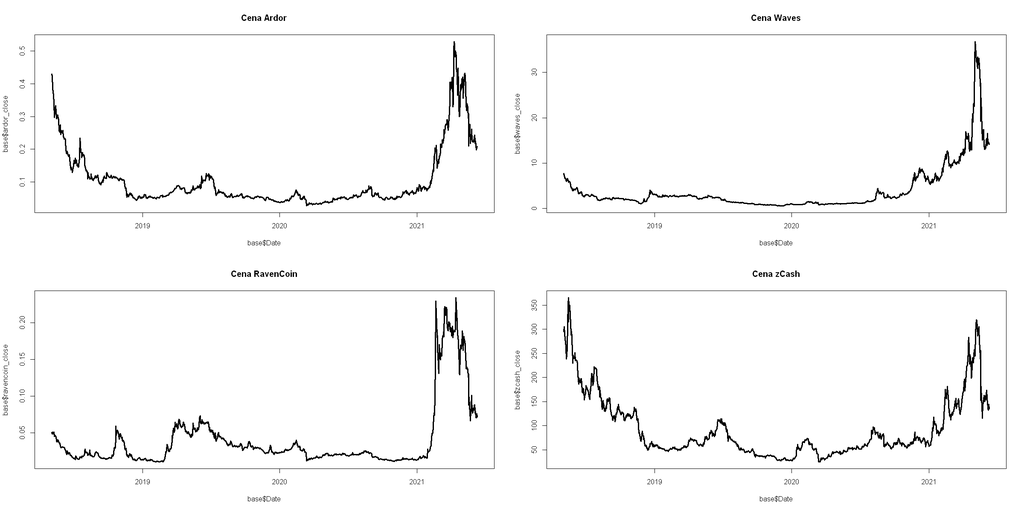

```r
par(mfrow=c(2,2))
plot(base$Date,base$ardor_close,type = "l",lwd=3, main="Cena Ardor")
plot(base$Date,base$waves_close,type = "l",lwd=3, main="Cena Waves")
plot(base$Date,base$ravencoin_close,type = "l",lwd=3, main="Cena RavenCoin")
plot(base$Date,base$zcash_close,type = "l",lwd=3, main="Cena zCash")
```

```r
dygraph(tot_ret_xts, main="Return rates for the entire portfolio") %>% dyRangeSelector(height = 50)
```

[interactive chart not shown]

In order to check whether there is an autocorrelation phenomenon in the portfolio returns, the graph of the autocorrelation function was analyzed.

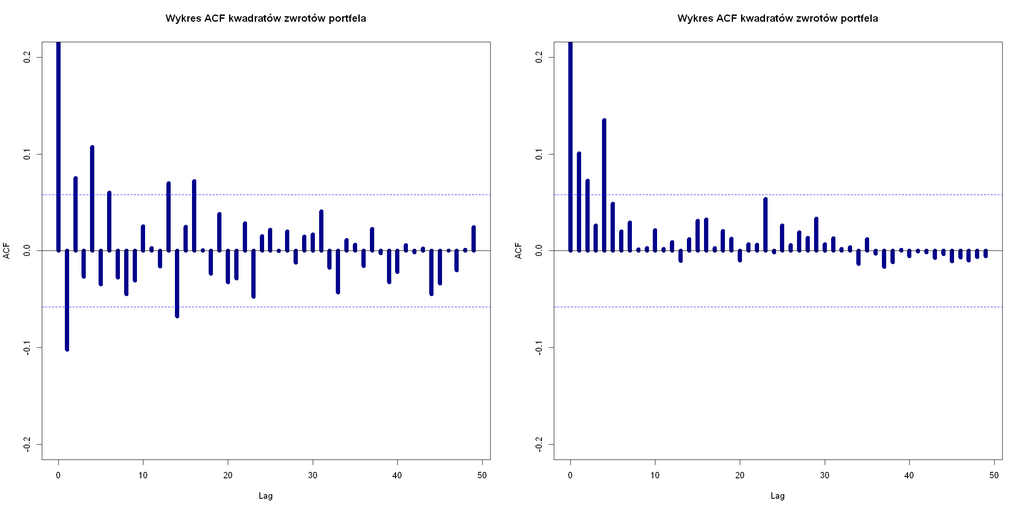

```r
par(mfrow=c(1,2))
acf(base$tot_ret, lag.max = 49, na.action = na.pass,
    ylim = c(-0.2, 0.2), # we rescale the vertical axis
    col = "darkblue", lwd = 8,
    main = "ACF Chart of Portfolio Returns Squares")
acf(base$tot_ret^2, lag.max = 49, na.action = na.pass,
    ylim = c(-0.2, 0.2), # we rescale the vertical axis
    col = "darkblue", lwd = 8,
    main = "ACF Chart of Portfolio Returns Squares")
```

```r
ArchTest(base$tot_ret, lags = 5)
```

```
	ARCH LM-test; Null hypothesis: no ARCH effects

data:  base$tot_ret
Chi-squared = 35.078, df = 5, p-value = 1.452e-06
```

```r
durbinWatsonTest(lm(base$tot_ret^2 ~ 1),
                 max.lag = 5) # First 5 delays
```

```
 lag Autocorrelation D-W Statistic p-value
   1      0.10076920      1.798436   0.026
   2      0.07238825      1.855138   0.040
   3      0.02645278      1.946953   0.228
   4      0.13520089      1.728525   0.022
   5      0.04862515      1.901633   0.100
 Alternative hypothesis: rho[lag] != 0
```

The test statistic of the ARCH LM test is 35.078 with its p-value almost 0, which can reject the null hypothesis that there are no ARCH effects in the portfolio. Based on the Durbin-Watson test, the null hypothesis of no autocorrelation for lags 1,2 and 4 can be rejected.

Moreover, when analyzing the histogram of the portfolio's return distribution, it can be noticed that it is strongly asymmetric on the left hand side.

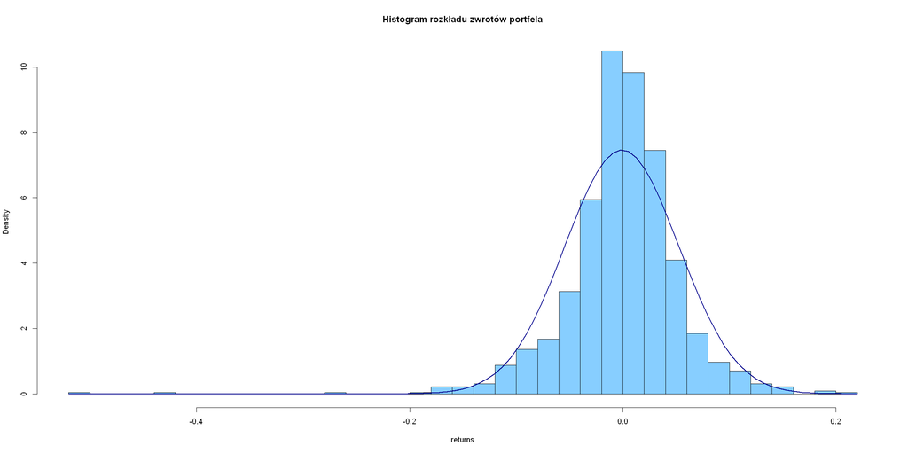

```r
hist(base$tot_ret, prob = T, breaks = 50, main = "Portfolio return distribution histogram", xlab="returns", col="skyblue1")
curve(dnorm(x, mean = mean(base$tot_ret, na.rm = T),
            sd  = sd(base$tot_ret, na.rm = T)),
            col = "darkblue", lwd = 2, add = TRUE,
            )
```

```r
basic_stats <- basicStats(base$tot_ret)
knitr::kable(as.matrix(basic_stats), digits = 2)
```

```
|            | X..base.tot_ret|
|:-----------|---------------:|
|nobs        |         1134.00|
|NAs         |            0.00|
|Minimum     |           -0.52|
|Maximum     |            0.20|
|1. Quartile |           -0.02|
|3. Quartile |            0.03|
|Mean        |            0.00|
|Median      |            0.00|
|Sum         |           -1.09|
|SE Mean     |            0.00|
|LCL Mean    |            0.00|
|UCL Mean    |            0.00|
|Variance    |            0.00|
|Stdev       |            0.05|
|Skewness    |           -1.49|
|Kurtosis    |           12.37|
```

```r
JB <- jarque.bera.test(na.omit(base$tot_ret))
JB
```

```
	Jarque Bera Test

data:  na.omit(base$tot_ret)
X-squared = 7683.1, df = 2, p-value < 2.2e-16
```

# 2. Sample split

```r
insample = base[which(base$Date <= '2020-12-12'),]
outsample = base[which(base$Date >= '2020-12-13'),]
```

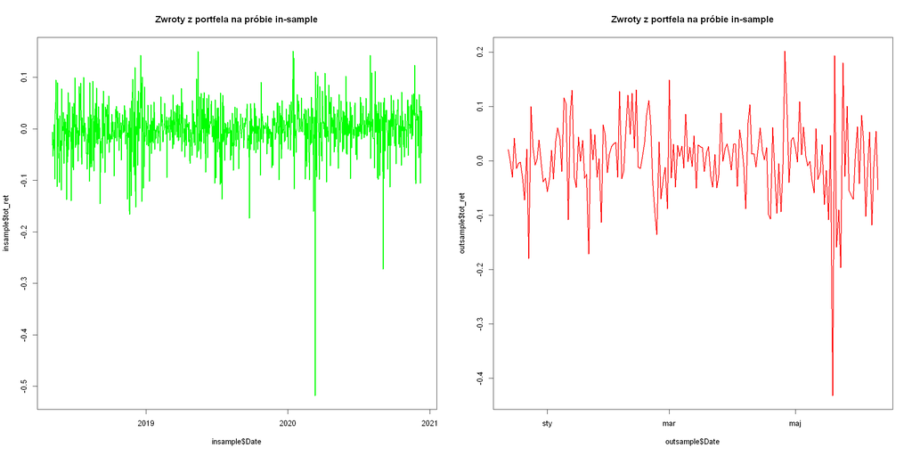

```r
par(mfrow=c(1,2))
plot(insample$Date, insample$tot_ret,
     type = 'l', lwd = 2, col = "green",
     main = 'In-sample wallet returns')
plot(outsample$Date, outsample$tot_ret,
     type = 'l', lwd = 2, col = "red",
     main = 'Out-of-sample wallet returns')
```

# 3. GARCH

The basic GARCH model that works well with most models is GARCH (1,1). The undoubted advantage of this model is the saving of parameters.

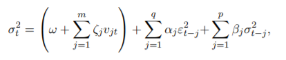

Below is an estimate of the GARCH (1,1) model via the "rugarch" package

```r
spec_garch <- ugarchspec(mean.model = list(armaOrder = c(0,0)),variance.model = list(model = 'sGARCH', garchOrder=c(1,1)))
garch <- ugarchfit(data = insample$tot_ret, spec = spec_garch)
garch
```

```
*---------------------------------*
*          GARCH Model Fit        *
*---------------------------------*

Conditional Variance Dynamics
-----------------------------------
GARCH Model	: sGARCH(1,1)
Mean Model	: ARFIMA(0,0,0)
Distribution	: norm

Optimal Parameters
------------------------------------
        Estimate  Std. Error  t value Pr(>|t|)
mu     -0.000864    0.001409 -0.61306 0.539834
omega   0.000162    0.000052  3.12151 0.001799
alpha1  0.124426    0.027590  4.50981 0.000006
beta1   0.819650    0.037800 21.68374 0.000000

Robust Standard Errors:
        Estimate  Std. Error  t value Pr(>|t|)
mu     -0.000864    0.001404 -0.61545 0.538260
omega   0.000162    0.000079  2.04431 0.040923
alpha1  0.124426    0.050633  2.45742 0.013994
beta1   0.819650    0.051086 16.04450 0.000000

LogLikelihood : 1574.775

Information Criteria
------------------------------------

Akaike       -3.2930
Bayes        -3.2726
Shibata      -3.2931
Hannan-Quinn -3.2853

Weighted Ljung-Box Test on Standardized Residuals
------------------------------------
                        statistic p-value
Lag[1]                    0.07906  0.7786
Lag[2*(p+q)+(p+q)-1][2]   0.10143  0.9187
```

[output cut: 36 more lines]

```
Negative Sign Bias  0.2126 0.8317
Positive Sign Bias  0.2259 0.8213
Joint Effect        2.8270 0.4191


Adjusted Pearson Goodness-of-Fit Test:
------------------------------------
  group statistic p-value(g-1)
1    20     85.16    2.360e-10
2    30     95.12    5.817e-09
3    40    110.07    1.072e-08
4    50    116.96    1.745e-07


Elapsed time : 0.09494495
```

The omega, alpha and betha parameters are significant at the 5% level, while the problem with irrelevance is noticeable at the average (mu).

You can use the following techniques to deal with the problem above:

- throwing it out
- changing the model layout
- changing p and q parameters for Garch
- Include ARIMA effects

The use of other parameters in GARCH did not bring the desired results. In this case, it was decided to use a distribution other than the normal one. There is no need to throw out a variable right away if there is a possibility of improving this state, so it was decided to use a different distribution than normal - SGED (Skew Generalized Error Distribution)

```r
spec_garch_sged <- ugarchspec(mean.model = list(armaOrder = c(0,0)),variance.model = list(model = 'sGARCH', garchOrder=c(1,1)),distribution.model=c('sged'))
garch_sged <- ugarchfit(data = insample$tot_ret, spec = spec_garch_sged)
garch_sged
```

```
*---------------------------------*
*          GARCH Model Fit        *
*---------------------------------*

Conditional Variance Dynamics
-----------------------------------
GARCH Model	: sGARCH(1,1)
Mean Model	: ARFIMA(0,0,0)
Distribution	: sged

Optimal Parameters
------------------------------------
        Estimate  Std. Error  t value Pr(>|t|)
mu     -0.001899    0.000858  -2.2138 0.026841
omega   0.000183    0.000055   3.3365 0.000848
alpha1  0.111114    0.028672   3.8753 0.000106
beta1   0.811065    0.039838  20.3593 0.000000
skew    0.868911    0.028020  31.0100 0.000000
shape   1.108322    0.062227  17.8109 0.000000

Robust Standard Errors:
        Estimate  Std. Error  t value Pr(>|t|)
mu     -0.001899    0.000591  -3.2114 0.001321
omega   0.000183    0.000043   4.2522 0.000021
alpha1  0.111114    0.023455   4.7373 0.000002
beta1   0.811065    0.029903  27.1228 0.000000
skew    0.868911    0.030947  28.0772 0.000000
shape   1.108322    0.080656  13.7414 0.000000

LogLikelihood : 1653.941

Information Criteria
------------------------------------

Akaike       -3.4548
Bayes        -3.4242
Shibata      -3.4549
Hannan-Quinn -3.4432

Weighted Ljung-Box Test on Standardized Residuals
```

[output cut: 42 more lines]

```
Negative Sign Bias  0.2014 0.8405
Positive Sign Bias  0.3177 0.7508
Joint Effect        3.2667 0.3523


Adjusted Pearson Goodness-of-Fit Test:
------------------------------------
  group statistic p-value(g-1)
1    20     29.69      0.05588
2    30     42.10      0.05500
3    40     51.45      0.08748
4    50     65.50      0.05763


Elapsed time : 0.5673509
```

After changing the distribution in the GARCH model, parameters that are not significant at the level of 5% no longer exist. The ARCH LM tests and the Ljung-Box test show no grounds for rejecting the null hypothesis of the lack of ARCH effects and the lack of autocorrelation. So the model explains the variance grouping and the autocorrelation.

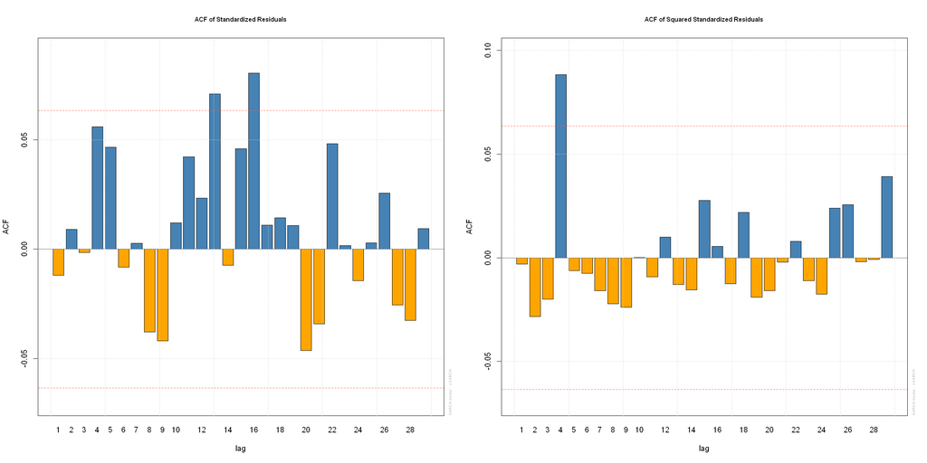

```r
par(mfrow=c(1,2))

plot(garch_sged, which = 10)
plot(garch_sged, which = 11)
```

Based on the Jarque-Ber test, reject the null hypothesis of residual normality.

```r
jarque.bera.test(na.omit(garch_sged@fit$residuals))
```

```
	Jarque Bera Test

data:  na.omit(garch_sged@fit$residuals)
X-squared = 8941.7, df = 2, p-value < 2.2e-16
```

```r
cat('Skew',skewness(x),'Kurtuoza',kurtosis(x) )
```

[output not shown]

# 4. EGARCH

To eliminate the leverage effect, the EGARCH model, which is often used in modeling financial data, was used. The log of variance is modeled, resulting in a positive variance value regardless of the parameter values.

The EGARCH (1,1) model is described by the following equations:

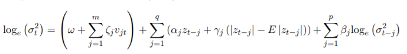

```r
egarch_spec <- ugarchspec(mean.model = list(armaOrder = c(0,0)),variance.model = list(model = 'eGARCH', garchOrder=c(1,1)))
egarch <- ugarchfit(data = insample$tot_ret, spec = egarch_spec)
egarch
```

```
*---------------------------------*
*          GARCH Model Fit        *
*---------------------------------*

Conditional Variance Dynamics
-----------------------------------
GARCH Model	: eGARCH(1,1)
Mean Model	: ARFIMA(0,0,0)
Distribution	: norm

Optimal Parameters
------------------------------------
        Estimate  Std. Error  t value Pr(>|t|)
mu     -0.001063    0.001428 -0.74433 0.456678
omega  -0.387403    0.141029 -2.74698 0.006015
alpha1 -0.040276    0.022069 -1.82499 0.068002
beta1   0.933775    0.023244 40.17307 0.000000
gamma1  0.212655    0.042013  5.06170 0.000000

Robust Standard Errors:
        Estimate  Std. Error  t value Pr(>|t|)
mu     -0.001063    0.001436 -0.74008 0.459252
omega  -0.387403    0.240519 -1.61069 0.107246
alpha1 -0.040276    0.045429 -0.88656 0.375317
beta1   0.933775    0.039079 23.89469 0.000000
gamma1  0.212655    0.061122  3.47916 0.000503

LogLikelihood : 1575.701

Information Criteria
------------------------------------

Akaike       -3.2929
Bayes        -3.2674
Shibata      -3.2929
Hannan-Quinn -3.2832

Weighted Ljung-Box Test on Standardized Residuals
------------------------------------
                        statistic p-value
```

[output cut: 39 more lines]

```
Negative Sign Bias  0.2109 0.8330
Positive Sign Bias  0.5622 0.5741
Joint Effect        2.0168 0.5689


Adjusted Pearson Goodness-of-Fit Test:
------------------------------------
  group statistic p-value(g-1)
1    20     87.68    8.534e-11
2    30     99.40    1.222e-09
3    40    112.00    5.593e-09
4    50    121.68    4.081e-08


Elapsed time : 0.131922
```

In the EGARCH (1,1) model mu and alpha turned out to be irrelevant. In order to use a different method of improving the model, in this case a function was used that creates all compilations of models with the determined minimum and maximum values of p and q and sorting in terms of the AIC criterion. In this case, it was decided to set the values of p and q in the range 1-6. The table below shows the best criterion value for P = 3 and Q = 6.

```r
tail(auto_garch(p_min=1,p_max=6, q_min=1, q_max=6,garch_type=c('eGARCH'),distribuation=c('norm')),2)
```

A data.frame: 2 × 8

|  | P <chr> | Q <chr> | Akaike <chr> | Bayes <chr> | Shibata <chr> | HannanQuinn <chr> | model <chr> | Distribuation <chr> |
| --- | --- | --- | --- | --- | --- | --- | --- | --- |
| 30 | 5 | 6 | -3.40220637711457 | -3.31049574180422 | -3.40290095449082 | -3.36727037024033 | eGARCH | norm |
| 18 | 3 | 6 | -3.40707498554877 | -3.3357444914185 | -3.40749745346439 | -3.3799025357577 | eGARCH | norm |

```r
egarch_spec_36 <- ugarchspec(mean.model = list(armaOrder = c(0,0)),variance.model = list(model = 'eGARCH', garchOrder=c(3,6)))
egarch36 <- ugarchfit(data = insample$tot_ret, spec = egarch_spec_36)
egarch36
```

```
*---------------------------------*
*          GARCH Model Fit        *
*---------------------------------*

Conditional Variance Dynamics
-----------------------------------
GARCH Model	: eGARCH(3,6)
Mean Model	: ARFIMA(0,0,0)
Distribution	: norm

Optimal Parameters
------------------------------------
        Estimate  Std. Error   t value Pr(>|t|)
mu     -0.000271    0.000000   -804.05        0
omega  -6.088023    0.000291 -20902.99        0
alpha1 -0.044641    0.000005  -9205.98        0
alpha2 -0.085363    0.000006 -13796.49        0
alpha3 -0.055310    0.000006  -9166.11        0
beta1  -0.999945    0.000064 -15526.59        0
beta2  -0.436743    0.000028 -15699.57        0
beta3   0.999935    0.000059  16988.67        0
beta4   0.586094    0.000031  18813.44        0
beta5   0.134490    0.000007  18149.88        0
beta6  -0.248458    0.000011 -21676.88        0
gamma1  0.499227    0.000027  18547.80        0
gamma2  0.644306    0.000040  16107.37        0
gamma3  0.472860    0.000027  17624.32        0

Robust Standard Errors:
        Estimate  Std. Error  t value Pr(>|t|)
mu     -0.000271    0.000002  -166.45        0
omega  -6.088023    0.001852 -3286.55        0
alpha1 -0.044641    0.000023 -1954.90        0
alpha2 -0.085363    0.000018 -4642.47        0
alpha3 -0.055310    0.000010 -5565.42        0
beta1  -0.999945    0.000862 -1159.90        0
beta2  -0.436743    0.000302 -1446.76        0
beta3   0.999935    0.000810  1233.94        0
beta4   0.586094    0.000077  7577.10        0
beta5   0.134490    0.000024  5707.61        0
```

[output cut: 66 more lines]

```
Negative Sign Bias  0.9306 0.3523
Positive Sign Bias  0.3307 0.7410
Joint Effect        2.4214 0.4897


Adjusted Pearson Goodness-of-Fit Test:
------------------------------------
  group statistic p-value(g-1)
1    20     43.27    0.0011888
2    30     65.56    0.0001197
3    40     72.67    0.0008548
4    50     76.92    0.0066045


Elapsed time : 1.500265
```

Changing the parameters remedied the problem of irrelevance of variables. The ARCH and Ljung-Box tests also in this case suggest no grounds for rejecting the hypotheses about the occurrence of ARCH effects and autocorrelation among the residuals.

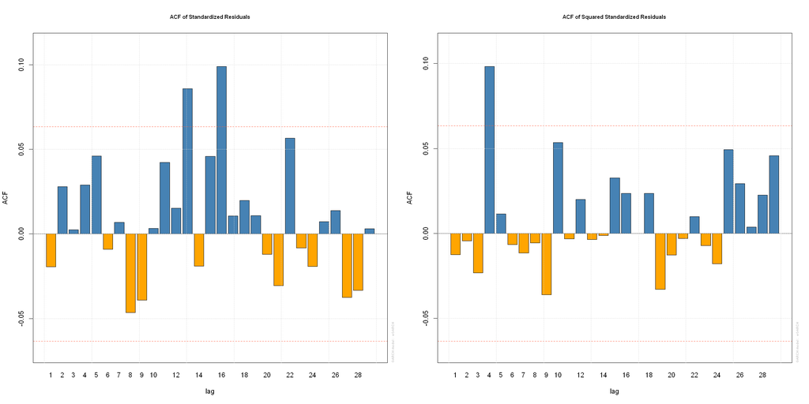

```r
par(mfrow=c(1,2))
plot(egarch36, which = 10)
plot(egarch36, which = 11)
```

ACF plots of standardized residuals and standardized squares for EGARCH (3,6) turned out to be very similar to those of the GARCH (1,1) model with SGED distribution.

```r
jarque.bera.test(na.omit(egarch36@fit$residuals))
```

[output not shown]

Also for the above model, the null hypothesis that the distribution of residuals is normal is rejected.

# 5. CGARCH

Component GARCH decomposes conditional variance into a constant and a transition term to investigate long and short term movements in variation.

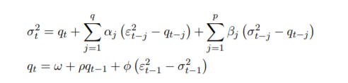

```r
spec_csgarch <- ugarchspec(mean.model = list(armaOrder = c(0,0)),variance.model = list(model = 'csGARCH', garchOrder=c(1,1)))
csgarch <- ugarchfit(data = insample$tot_ret, spec = spec_csgarch)
csgarch
```

```
*---------------------------------*
*          GARCH Model Fit        *
*---------------------------------*

Conditional Variance Dynamics
-----------------------------------
GARCH Model	: csGARCH(1,1)
Mean Model	: ARFIMA(0,0,0)
Distribution	: norm

Optimal Parameters
------------------------------------
        Estimate  Std. Error     t value Pr(>|t|)
mu     -0.000799    0.001402 -5.7011e-01  0.56860
omega   0.000011    0.000000  3.0627e+01  0.00000
alpha1  0.121182    0.013567  8.9324e+00  0.00000
beta1   0.822114    0.009869  8.3300e+01  0.00000
eta11   0.996090    0.000000  6.8581e+06  0.00000
eta21   0.000002    0.000025  8.8760e-02  0.92927

Robust Standard Errors:
        Estimate  Std. Error     t value Pr(>|t|)
mu     -0.000799    0.001409 -5.6710e-01 0.570644
omega   0.000011    0.000001  1.5548e+01 0.000000
alpha1  0.121182    0.032115  3.7734e+00 0.000161
beta1   0.822114    0.045441  1.8092e+01 0.000000
eta11   0.996090    0.000000  3.8662e+06 0.000000
eta21   0.000002    0.000033  6.8810e-02 0.945141

LogLikelihood : 1574.289

Information Criteria
------------------------------------

Akaike       -3.2878
Bayes        -3.2572
Shibata      -3.2879
Hannan-Quinn -3.2762

Weighted Ljung-Box Test on Standardized Residuals
```

[output cut: 42 more lines]

```
Negative Sign Bias  0.1983 0.8429
Positive Sign Bias  0.2461 0.8057
Joint Effect        2.7684 0.4287


Adjusted Pearson Goodness-of-Fit Test:
------------------------------------
  group statistic p-value(g-1)
1    20     84.74    2.794e-10
2    30     94.05    8.558e-09
3    40    107.05    2.939e-08
4    50    113.19    5.439e-07


Elapsed time : 0.1275342
```

There are also irrelevant variables for this model. In order to get rid of the irrelevance of mu and eta21, a different approach was used this time - adding ARMA effects to the model. As in the previous model, a function creating N models based on selected parameters was used, but this time the function is based on the AR and MA parameters. Values ranging from 1-5 were selected. The best parameters in terms of the Akaike criterion are characterized by the model with the values of AR and MA 5.

```r
tail(auto_garch_arma(p_min=1,p_max=5, q_min=1, q_max=5,garch_type=c('csGARCH'),distribuation=c('norm'),p_garch=1,q_garch=1),2)
```

A data.frame: 2 × 8

|  | P <chr> | Q <chr> | Akaike <chr> | Bayes <chr> | Shibata <chr> | HannanQuinn <chr> | model <chr> | Distribuation <chr> |
| --- | --- | --- | --- | --- | --- | --- | --- | --- |
| 24 | 5 | 4 | -3.29886008831671 | -3.22243455889142 | -3.29934440359325 | -3.26974674925484 | csGARCH | norm |
| 25 | 5 | 5 | -3.29916606422082 | -3.21764549950051 | -3.29971635800568 | -3.26811183588816 | csGARCH | norm |

```r
spec_csgarch55 <- ugarchspec(mean.model = list(armaOrder = c(5,5)),variance.model = list(model = 'csGARCH', garchOrder=c(1,1)))
csgarch55 <- ugarchfit(data = insample$tot_ret, spec = spec_csgarch55)
csgarch55
```

```
*---------------------------------*
*          GARCH Model Fit        *
*---------------------------------*

Conditional Variance Dynamics
-----------------------------------
GARCH Model	: csGARCH(1,1)
Mean Model	: ARFIMA(5,0,5)
Distribution	: norm

Optimal Parameters
------------------------------------
        Estimate  Std. Error    t value Pr(>|t|)
mu     -0.000737    0.000008    -95.284        0
ar1    -0.656445    0.000142  -4631.216        0
ar2     0.290066    0.000079   3688.462        0
ar3     0.286176    0.000073   3922.393        0
ar4    -0.266666    0.000056  -4789.582        0
ar5    -0.596403    0.000132  -4514.734        0
ma1     0.632616    0.000016  38468.810        0
ma2    -0.261376    0.000009 -27801.791        0
ma3    -0.247230    0.000062  -3981.443        0
ma4     0.355635    0.000040   8889.227        0
ma5     0.730584    0.000047  15391.438        0
omega   0.000008    0.000001     11.535        0
alpha1  0.114518    0.000697    164.339        0
beta1   0.831130    0.003397    244.671        0
eta11   0.996911    0.000200   4991.276        0
eta21   0.000952    0.000006    168.620        0

Robust Standard Errors:
        Estimate  Std. Error    t value Pr(>|t|)
mu     -0.000737    0.000138    -5.3473        0
ar1    -0.656445    0.000623 -1052.9586        0
ar2     0.290066    0.000114  2549.8198        0
ar3     0.286176    0.000307   932.3123        0
ar4    -0.266666    0.000414  -644.7193        0
ar5    -0.596403    0.000524 -1137.8831        0
ma1     0.632616    0.000054 11668.4955        0
ma2    -0.261376    0.000036 -7342.1566        0
```

[output cut: 72 more lines]

```
Negative Sign Bias 0.08889 0.9292
Positive Sign Bias 0.07898 0.9371
Joint Effect       1.86062 0.6018


Adjusted Pearson Goodness-of-Fit Test:
------------------------------------
  group statistic p-value(g-1)
1    20     70.91    6.499e-08
2    30     84.43    2.558e-07
3    40    101.43    1.849e-07
4    50    121.68    4.081e-08


Elapsed time : 0.8490319
```

The use of AR and MA also allowed us to deal with the irrelevance of the variables. The tests also suggest that there is no basis for rejecting the hypotheses about the existence of ARCH effects and autocorrelation among the residuals.

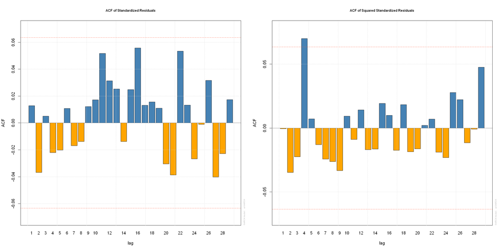

```r
par(mfrow=c(1,2))
plot(csgarch55, which = 10)
plot(csgarch55, which = 11)
```

The ACF plots of standardized residuals and squares of standardized residuals for this model differ significantly from the previously estimated models. No lag is significant for the standardized residuals, while the fourth lag is still significant when plotting the squares of the standardized residuals. Again, the Jarque-Bera test indicates that the residuals in the model are not normal.

```r
jarque.bera.test(na.omit(csgarch55@fit$residuals))
```

```
	Jarque Bera Test

data:  na.omit(csgarch55@fit$residuals)
X-squared = 6463.1, df = 2, p-value < 2.2e-16
```

In this case, we also reject the null hypothesis of normal residual distribution.

# 6. Comparison of models

The estimated models showed similar results in the diagnostic tests. To compare which of them is better suited to the analyzed portfolio, the Akaike, Bayes, Shibat and Hannan_Quinn information criteria were used. The best information criteria values are found in sged-GARCH (1,1).

```r
model <- c(0)
Akaike <- c(0)
Bayes <- c(0)
Shibata <- c(0)
HannanQuinn <- c(0)
output <- data.frame(model,Akaike,Bayes,Shibata,HannanQuinn)

output[1,]=c('sged-GARCH (1,1)', infocriteria(garch_sged)[1],infocriteria(garch_sged)[2],infocriteria(garch_sged)[3],infocriteria(garch_sged)[4] )
output[2,]=c('norm-EGARCH (3,6)', infocriteria(egarch36)[1],infocriteria(egarch36)[2],infocriteria(egarch36)[3],infocriteria(egarch36)[4] )
output[3,]=c('norm-CSGARCH(1,1)x(5,0,5)', infocriteria(csgarch55)[1],infocriteria(csgarch55)[2],infocriteria(csgarch55)[3],infocriteria(csgarch55)[4] )

output
```

A data.frame: 3 × 5

|  | model <chr> | Akaike <chr> | Bayes <chr> | Shibata <chr> | HannanQuinn <chr> |
| --- | --- | --- | --- | --- | --- |
| 1 | sged-GARCH (1,1) | -3.45480301286154 | -3.42423280109142 | -3.45488146644951 | -3.44315767723679 |
| 2 | norm-EGARCH (3,6) | -3.40707498554877 | -3.3357444914185 | -3.40749745346439 | -3.3799025357577 |
| 3 | norm-CSGARCH(1,1)x(5,0,5) | -3.29916606422082 | -3.21764549950051 | -3.29971635800568 | -3.26811183588816 |

```r
model <- c(0)
unconditional variance <- c(0)
output <- data.frame(model,unconditional variance)
output[1,]=c('sged-GARCH (1,1)', uncvariance(garch_sged))
output[2,]=c('norm-EGARCH (3,6)', uncvariance(egarch36) )
output[3,]=c('norm-CSGARCH(1,1)x(5,0,5)', uncvariance(csgarch55) )
output
```

A data.frame: 3 × 2

[output not shown]

The EGARCH model has the lowest unconditional variance.

# 7. Value at Risk

The "ugarchroll" function was used to estimate 1% of the value at risk. The Value at Risk computation starts with the first observation in the out-of-sample set.

```r
garch_f <- ugarchroll(spec_garch_sged, base$tot_ret, n.start=956,refit.every = 25, refit.window = "moving",VaR.alpha = 0.01)
egarch_f <- ugarchroll(egarch_spec_36, base$tot_ret, n.start=956,refit.every = 25, refit.window = "moving",VaR.alpha = 0.01)
csgarch_f <- ugarchroll(spec_csgarch55, base$tot_ret, n.start=956,refit.every = 25, refit.window = "moving",VaR.alpha = 0.01)
```

```r
VaRGARCH <- garch_f@forecast$VaR[,1]
VaREGARCH <- egarch_f@forecast$VaR[,1]
VaRCGARCH <- csgarch_f@forecast$VaR[,1]
```

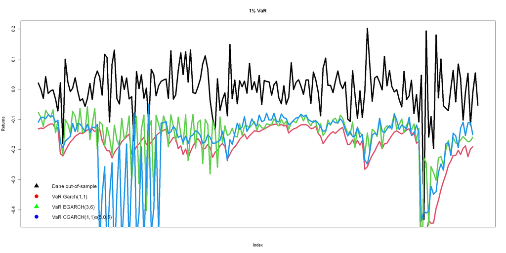

```r
plot(outsample$tot_ret, type = "l",
     ylab = "Returns", main = "1% VaR", xaxt = "n", col=1,lwd=5)
lines(VaRGARCH, col = 2, lwd=5)
lines(VaREGARCH, col = 3,lwd=5)
lines(VaRCGARCH, col = 4,lwd=5 )

legend("bottomleft",
  legend = c("Dane out-of-sample", "VaR Garch(1,1)", 'VaR EGARCH(3,6)', 'VaR CGARCH(1,1)x(5,0,5)'),
  col = c('black', 'red', 'green', 'blue'),
  pch = c(17,19),
  bty = "n",
  pt.cex = 2,
  cex = 1.2,
  text.col = "black",
  horiz = F )
```

Value at Risk is the most stable for the sged-GARCH (1,1) model. There is too much hesitation with the EGARCH and CGARCH models.

# 8. Sensitivity Analysis

To check the sensitivity of the influence of in-sample and out-of-sample trials on model estimates and conclusions, the out-of-sample trial period has been extended, which this time starts from 2020-06-10 and has 365 observations, including thus shortening the in-sample by 186 observations

```r
insample2 = base[which(base$Date <= '2020-06-10'),]
outsample2 = base[which(base$Date >= '2020-06-11'),]
```

```r
garch_f2 <- ugarchroll(spec_garch_sged, base$tot_ret, n.start=770,refit.every = 25, refit.window = "moving",VaR.alpha = 0.01)
egarch_f2 <- ugarchroll(egarch_spec_36, base$tot_ret, n.start=770,refit.every = 25, refit.window = "moving",VaR.alpha = 0.01)
csgarch_f2 <- ugarchroll(spec_csgarch55, base$tot_ret, n.start=770,refit.every = 25, refit.window = "moving",VaR.alpha = 0.01)
```

```r
VaRGARCH2 <- garch_f2@forecast$VaR[,1]
VaREGARCH2 <- egarch_f2@forecast$VaR[,1]
VaRCGARCH2 <- csgarch_f2@forecast$VaR[,1]
```

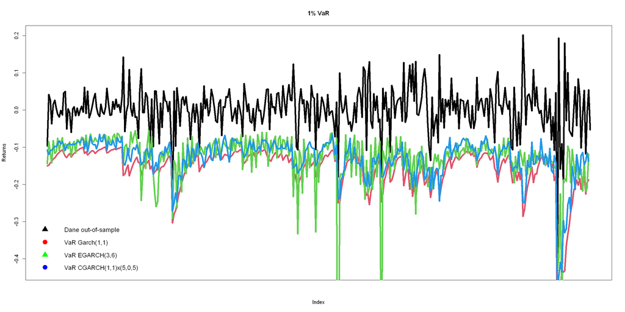

```r
plot(outsample2$tot_ret, type = "l",
     ylab = "Returns", main = "1% VaR", xaxt = "n", col=1,lwd=5)
lines(VaRGARCH2, col = 2, lwd=5)
lines(VaREGARCH2, col = 3,lwd=5)
lines(VaRCGARCH2, col = 4,lwd=5 )

legend("bottomleft",
  legend = c("Dane out-of-sample", "VaR Garch(1,1)", 'VaR EGARCH(3,6)', 'VaR CGARCH(1,1)x(5,0,5)'),
  col = c('black', 'red', 'green', 'blue'),
  pch = c(17,19),
  bty = "n",
  pt.cex = 2,
  cex = 1.2,
  text.col = "black",
  horiz = F )
```

By increasing the number of observations in the out-of-sample sample, the Value at Risk for the CGARCH model improved significantly. The EGARCH model deteriorated, too, as it overextended in 4 periods in this sample and was subject to greater fluctuations than before the extension of this sample.

# Conclusions